[OHI British Columbia](http://www.ohibc.org/) | [OHI Science](http://ohi-science.org) | [Citation policy](https://github.com/OHI-Science/ohiprep/releases)

# OHIBC: Ocean Acidification Pressure layers prep

Compiled on Tue Jul 18 16:34:23 2017 by ohara

# 1 Summary

This layer will determine ocean acidification values from the global rate of change layers; these layers already scale OA pressures appropriately. The rescaling is based on the changes in aragonite saturation state according to:

$$\Delta \Omega_{year} = \frac{(\Omega_{base} - \Omega_{year})}{(\Omega_{base} - 1)}$$

In the global analysis, pressures for 2011-2016 are available with this rescaling; however, for this OHIBC analysis, we will begin with the global rasters for annual mean aragonite saturation state values, crop to BC, interpolate using inverse distance weighting, and then reproject to approx 1 km resolution (from CHI).

# 2 Data

This script captures OA spatial data from the OHI Global assessments and determines scores for each OHIBC region.

The OA data layers for OHI Global are located on Mazu:

```
##  [1] "/home/shares/ohi/git-annex/globalprep/prs_oa/v2015/output/annual_oa_rescaled_1km_int_clip_2005.tif"
##  [2] "/home/shares/ohi/git-annex/globalprep/prs_oa/v2015/output/annual_oa_rescaled_1km_int_clip_2006.tif"
##  [3] "/home/shares/ohi/git-annex/globalprep/prs_oa/v2015/output/annual_oa_rescaled_1km_int_clip_2007.tif"
##  [4] "/home/shares/ohi/git-annex/globalprep/prs_oa/v2015/output/annual_oa_rescaled_1km_int_clip_2008.tif"
##  [5] "/home/shares/ohi/git-annex/globalprep/prs_oa/v2015/output/annual_oa_rescaled_1km_int_clip_2009.tif"
##  [6] "/home/shares/ohi/git-annex/globalprep/prs_oa/v2015/output/annual_oa_rescaled_1km_int_clip_2010.tif"
##  [7] "/home/shares/ohi/git-annex/globalprep/prs_oa/v2015/output/annual_oa_rescaled_1km_int_clip_2011.tif"
##  [8] "/home/shares/ohi/git-annex/globalprep/prs_oa/v2015/output/annual_oa_rescaled_1km_int_clip_2012.tif"
##  [9] "/home/shares/ohi/git-annex/globalprep/prs_oa/v2015/output/annual_oa_rescaled_1km_int_clip_2013.tif"
## [10] "/home/shares/ohi/git-annex/globalprep/prs_oa/v2015/output/annual_oa_rescaled_1km_int_clip_2014.tif"
## [11] "/home/shares/ohi/git-annex/globalprep/prs_oa/v2016/output/oa_prs_layer_2011.tif"
## [12] "/home/shares/ohi/git-annex/globalprep/prs_oa/v2016/output/oa_prs_layer_2012.tif"
## [13] "/home/shares/ohi/git-annex/globalprep/prs_oa/v2016/output/oa_prs_layer_2013.tif"
## [14] "/home/shares/ohi/git-annex/globalprep/prs_oa/v2016/output/oa_prs_layer_2014.tif"
## [15] "/home/shares/ohi/git-annex/globalprep/prs_oa/v2016/output/oa_prs_layer_2015.tif"
## [16] "/home/shares/ohi/git-annex/globalprep/prs_oa/v2017/output/oa_prs_layer_2016.tif"
```

**NOTE**: The 2005-2014 layers from v2015 are using the old reference point method (any change is same pressure regardless of how close to 1). The v2016 and v2017 layers use the new reference point (reductions in arag sat state closer to one are penalized more heavily). So 2005-2010 layers will need to be redone in this script using the new reference point; we will just do all the layers from scratch (starting with OHI mean aragonite saturation state calculations) for consistency.

## 2.1 Data Source for global OA layer:

- **Reference**: [Feely et al.(2009)](https://darchive.mblwhoilibrary.org/bitstream/handle/1912/3180/22-4_feely.pdf?sequence=1&isAllowed=y)
- **Downloaded**: March 15, 2016
- **Description**: Aragonite Saturation State $\Omega_{arg}$
- **Native data resolution**: 1 degree cells
- **Time range**: 1880-1889 and 2005-2100, monthly data provided for each year. Future years are based on model projections for RCP 8.5. Previous years are hindcast/historical data.
- **Format**: NetCDF

The global OA data prep script performs the following operations:

1. Calculates the annual mean for 2016
2. Rescales each annual raster layer from 0 to 1 based on a biological threshold (Ω <= 1) and the proportional change compared to a historical mean
3. Interpolates the data to gap-fill for cells where there is no data
4. Resamples the rescaled raster layer to 1km^2 cell resolution
5. Mask the resampled data to select only those cells within the ocean

# 3 Methods

## 3.1 Create Mollweide OHIBC regions

Since the pressures layers are created in Mollweide projection for OHI Global, we will create a Mollweide version of the OHIBC regions for defining the analysis. This allows us to avoid reprojecting the raster and adding another layer of resampling.

## 3.2 Recreate OA pressures for BC using nonlinear rescaling

To recreate the BC layers using the current reference point, we load from OHI global these rasters:

- the historic reference point raster
- the annual mean rasters for the study years.

The calculation is performed using the same method as the global layers. First step is to clip the global rasters to the extents of OHIBC, maintaining the original projection (Mollweide) and resolution to avoid coloring the underlying data any more than necessary.

### 3.2.1 Animate OA mean aragonite sat state rasters

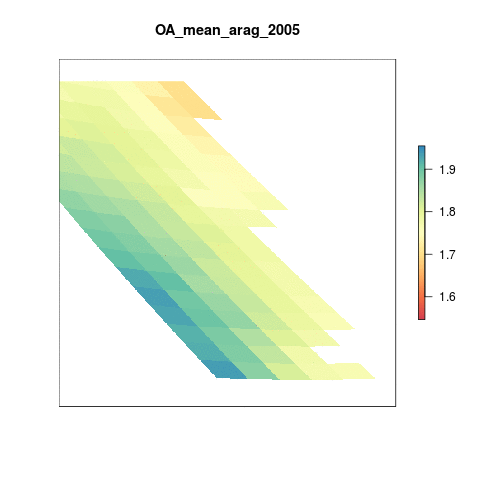

## 3.3 Rescale from 0 to 1

This pressure layer is rescaled so that all values lie between 0 and 1 using both a historical reference period and a biological reference point. All cells with values less than one, indicating an undersaturated state, are set equal to the highest stressor level, 1. For all other cells, rescaling the aragonite staturation state value to between 0 and 1 relies upon the change in saturation relative to the reference period.

### 3.3.1 Historical Mean

The historical mean &#937 aragonite saturation state from 1880 - 1889 was calculated for OHI 2015. The same raster was used for OHI 2016 and is again used here as the baseline.

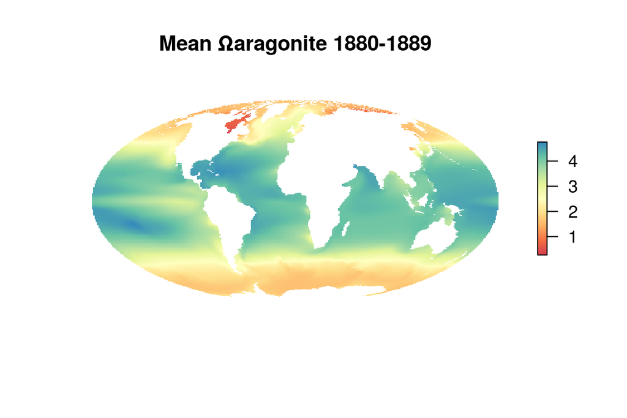

### 3.3.2 Rescale values at original resolution

### 3.3.3 Interpolate

Since there are oceanic cells with no information in the raw data, we need to fill in these gaps. We do this by interpolating across the globe using the data we have with an Inverse Distance Weighting (IDW) function. Previously in Global (prior to 2017) this was done using `arcpy` from ArcGIS.

### 3.3.4 Reproject to new resolution

Using a global ocean raster (cropped to BC extents) as a template, resample the rescaled and interpolated rasters using nearest neighbor (ngb does not change the underlying values, as occurs with bilinear or bicubic), and mask land cells from the analysis.

### 3.3.5 Animate OA pressures rasters

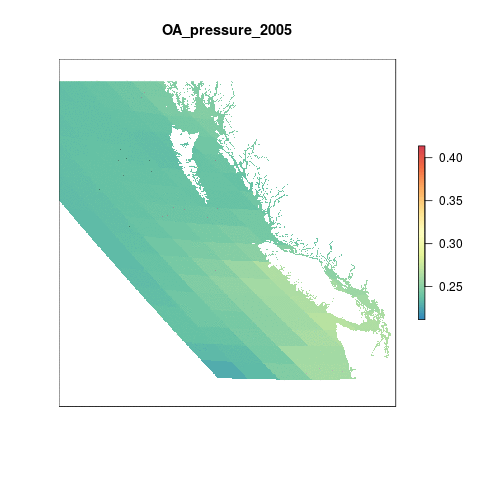

### 3.3.6 Check “local” calculations against global calcs

Since this local calculation depends on cropping the global raster prior to interpolating, small differences may arise due to shifts in the raster origin or loss of nearby cell values due to cropping. Here we briefly compare a locally-calculated raster to the cropped global for verification. We will use the 2012 rasters for comparison.

Local calculation is that it depends on smaller input files (at larger resolutions) than using pre-calculated global rasters. If little difference is noted, local calculation may be a big advantage for OHI+ users, who would no longer need to handle or process global fine-scale rasters for this pressure layer.

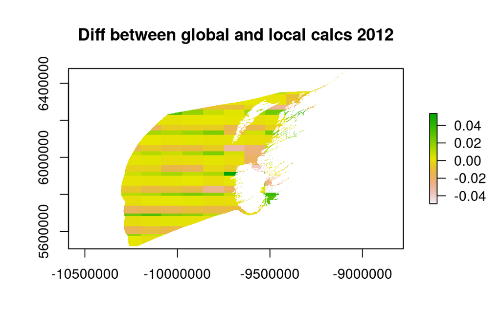

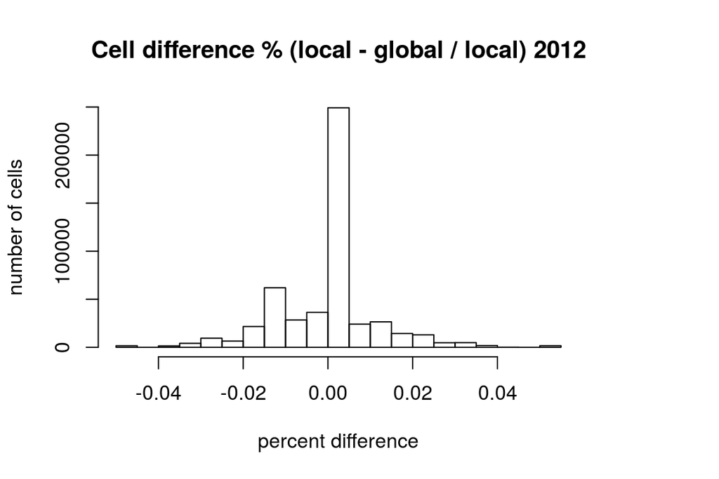

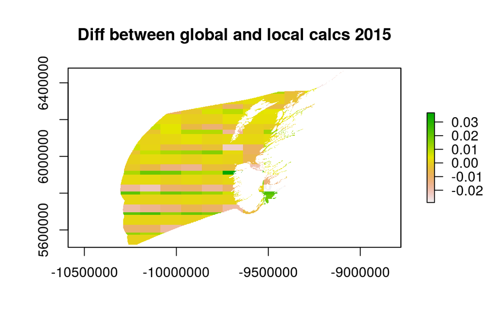

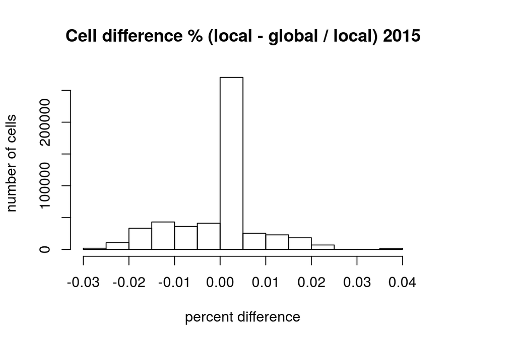

Differences cluster in a reasonably normal distribution around zero, with mean = -0.0004717973 and sd = 0.01188621.

## 3.4 Calculate mean pressures per region

For each year, pull in the pressure raster and run zonal stats to find mean pressure in each region for each year.

|  | rgn_id | year | pressure |
| --- | --- | --- | --- |
| 1 | 1 | 2005 | 0.241543581425075 |
| 2 | 2 | 2005 | 0.239381379318494 |
| 3 | 3 | 2005 | 0.242139623059917 |
| 4 | 4 | 2005 | 0.248905358543825 |
| 5 | 5 | 2005 | 0.261941537564122 |
| 6 | 6 | 2005 | 0.256912034747431 |
| 7 | 7 | 2005 | 0.240296469268228 |
| 8 | 8 | 2005 | 0.237856711186061 |
| 9 | 1 | 2006 | 0.258751428130615 |
| 10 | 2 | 2006 | 0.254950830874779 |

[output cut: 118 more lines]

## 3.5 Calculate gapfilling proportional areas

Using a pressure raster prior to the interpolation step, we resample at the 934 m resolution, replacing cells with non-NA values with a 1 and cells with NA value with -1.

Taking a mean of this layer by OHIBC region will give a value between -1 (100% gapfill) and +1 (0% gapfill).

|  | rgn_id | pct_gf |
| --- | --- | --- |
| 1 | 1 | 0.3206744236156 |
| 2 | 2 | 0.0239095252774353 |
| 3 | 3 | 0.108748645720477 |
| 4 | 4 | 0.438407329105004 |
| 5 | 5 | 0.0408537549407115 |
| 6 | 6 | 1 |
| 7 | 7 | 0.000946647290844926 |
| 8 | 8 | 0.003349148758024 |

# 4 Provenance

- *Run ID: 6 (afc55ce); run tag: “standard run”*
- *Run elapsed time: 3712.831 seconds; run memory usage: 6984 MB*
- *System info:*
  - *System: Linux, Release: 4.4.0-57-generic. Machine: x86_64. User: ohara.*
  - *R version: R version 3.4.1 (2017-06-30), Platform: x86_64-pc-linux-gnu, Running under: Ubuntu 14.04.5 LTS.*
  - *Attached base packages: stats, graphics, grDevices, utils, datasets, methods, base*
  - *Other attached packages: gstat_1.1-5, provRmd_0.1.1, stringr_1.2.0, RColorBrewer_1.1-2, dplyr_0.5.0, purrr_0.2.2, readr_1.1.0, tidyr_0.6.2, tibble_1.3.3, ggplot2_2.2.1.9000, tidyverse_1.1.1, raster_2.5-8, rgdal_1.2-8, sp_1.2-5*

[figure not shown]

| sequence | file_name | parent_chunk | file_dir | filetype | uncomm_chgs | commit_hash_short |
| --- | --- | --- | --- | --- | --- | --- |
| 0 | pressures_oa_prep.Rmd | unnamed-chunk-2 | ~/github/ohibc/prep/_pressures/v2017 | parent_script | True | 4fc723a |
| 0 | pressures_oa_prep.Rmd#animate_mean_arag_state | animate_mean_arag_state | ~/github/ohibc/prep/_pressures/v2017 | parent_chunk | True | 4fc723a |
| 0 | pressures_oa_prep.Rmd#calc_gapfills | calc_gapfills | ~/github/ohibc/prep/_pressures/v2017 | parent_chunk | True | 4fc723a |
| 0 | pressures_oa_prep.Rmd#check_rasts | check_rasts | ~/github/ohibc/prep/_pressures/v2017 | parent_chunk | True | 4fc723a |
| 0 | pressures_oa_prep.Rmd#clip_rasts_to_bc_extents | clip_rasts_to_bc_extents | ~/github/ohibc/prep/_pressures/v2017 | parent_chunk | True | 4fc723a |
| 0 | pressures_oa_prep.Rmd#compare_local_method_to_global | compare_local_method_to_global | ~/github/ohibc/prep/_pressures/v2017 | parent_chunk | True | 4fc723a |
| 0 | pressures_oa_prep.Rmd#create_ohibc_rgn_mol | create_ohibc_rgn_mol | ~/github/ohibc/prep/_pressures/v2017 | parent_chunk | True | 4fc723a |
| 0 | pressures_oa_prep.Rmd#determine_gapfills | determine_gapfills | ~/github/ohibc/prep/_pressures/v2017 | parent_chunk | True | 4fc723a |
| 0 | pressures_oa_prep.Rmd#get_mean_pressures | get_mean_pressures | ~/github/ohibc/prep/_pressures/v2017 | parent_chunk | True | 4fc723a |
| 0 | pressures_oa_prep.Rmd#histMean | histMean | ~/github/ohibc/prep/_pressures/v2017 | parent_chunk | True | 4fc723a |

[output cut: 179 more lines]